# Marine Spatial PLanning

Moegamad Uzair Jack

2025-06-02

## Loading packages

```r
library(tidyverse)
library(ggpubr)
library(vegan)
```

## Reading File

Reading csv as a data frame

```r
EF <- read.csv('EstuaryFishSurveyData.csv')
class(EF)
```

```
## [1] "data.frame"
```

Replace NA values with 0

```r
EF[is.na(EF)] <- 0
```

## Alpha Diversity

Creating a separate column

```r
EF$alpha <- specnumber(EF[4: 148])
```

Plotting alpha diversity (species number) per estuary

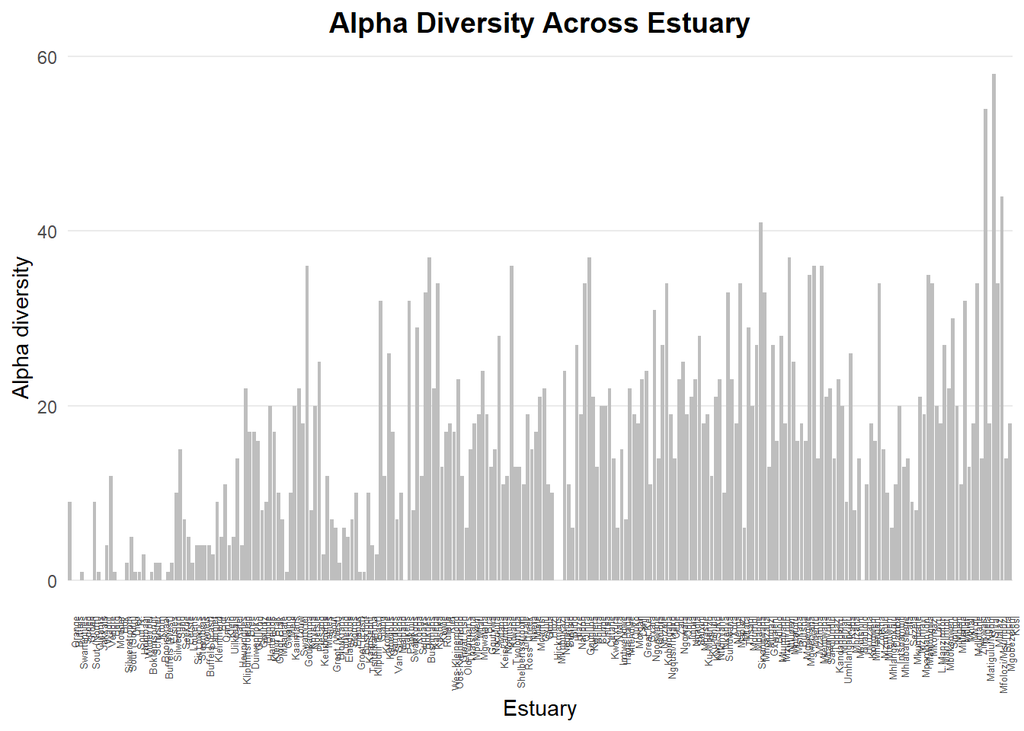

```r
EF$Estuary <- factor(EF$Estuary, levels = unique(EF$Estuary)) # Ensure Estuary is a factor for ordered x-axis labels

g1 <- ggplot(EF, aes(x = Estuary, y = alpha)) +
  geom_bar(stat = "identity", fill = "grey") +
  theme_minimal() +
  labs(
    title = "Alpha Diversity Across Estuary",
    x = "Estuary",
    y = "Alpha diversity"
  ) +
  theme(axis.text.x = element_text(angle = 90, hjust = 1, size = 5),
    plot.title = element_text(size = 14, face = "bold", hjust = 0.5),
    panel.grid.major.x = element_blank(),
    panel.grid.minor = element_blank()
        )
g1
```

## SW Diversity

```r
EF$SW <- diversity(EF[4:148], index = "shannon")
```

Creating kmEast column

```r
EF$kmEast <- 3000 - EF$kmWest
```

## Plots

Plotting alpha diveristy vs. km East

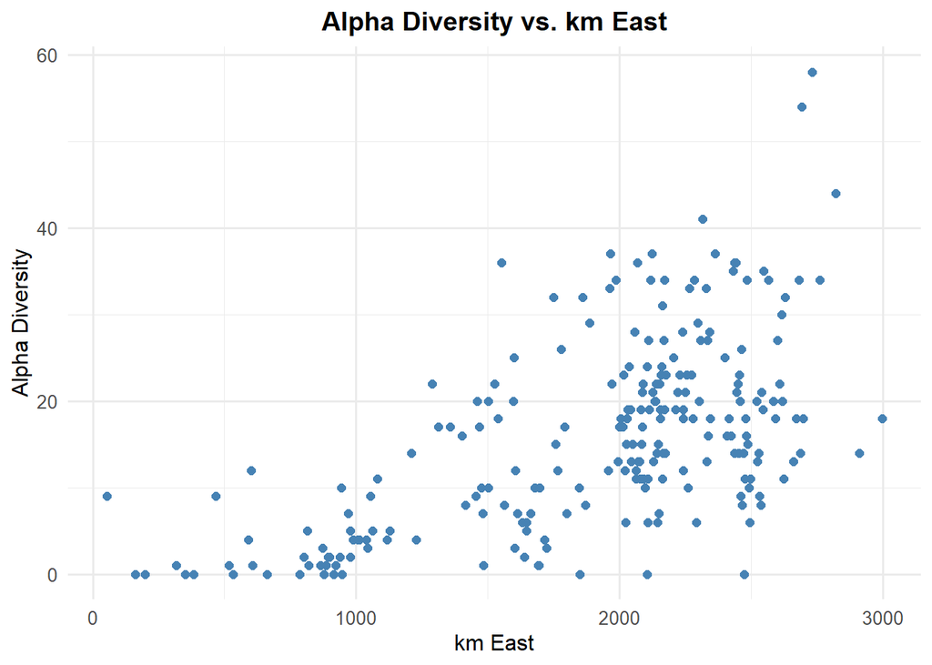

```r
g2 <- ggplot(EF, aes(x = kmEast, y = alpha)) +
  geom_point(color = "steelblue", size = 2) +
  theme_minimal(base_size = 12) +
  labs(
    title = "Alpha Diversity vs. km East",
    x = "km East",
    y = "Alpha Diversity"
  ) +
  theme(
    plot.title = element_text(face = "bold", hjust = 0.5),
    axis.title = element_text(size = 12),
    axis.text = element_text(size = 10)
  )
g2
```

Plotting Shannon–Wiener Diversity vs. km East

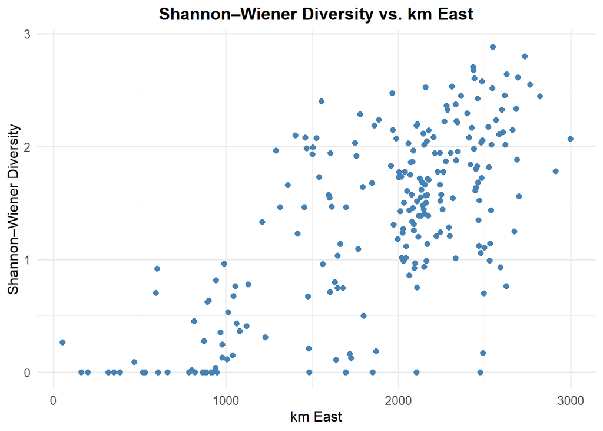

```r
g3 <- ggplot(EF, aes(x = kmEast, y = SW)) +
  geom_point(color = "steelblue", size = 2) +
  theme_minimal(base_size = 12) +
  labs(
    title = "Shannon–Wiener Diversity vs. km East",
    x = "km East",
    y = "Shannon–Wiener Diversity"
  ) +
  theme(
    plot.title = element_text(face = "bold", hjust = 0.5),
    axis.title = element_text(size = 12),
    axis.text = element_text(size = 10)
  )
g3
```

## Data frame manipulation

Reorder data frame

```r
EF <- EF[order(-EF$alpha), ]
```

Creating new variable

```r
EF$AlphaList <- 0
EF$AlphaList[1:20] <- 1
```

## Plots

Plot top 20 in RED and the rest in BLACK Plot the alpha diversity against km East with colour factor based on the alpha rank. Here the top 20 are represented in red and the rest in black.

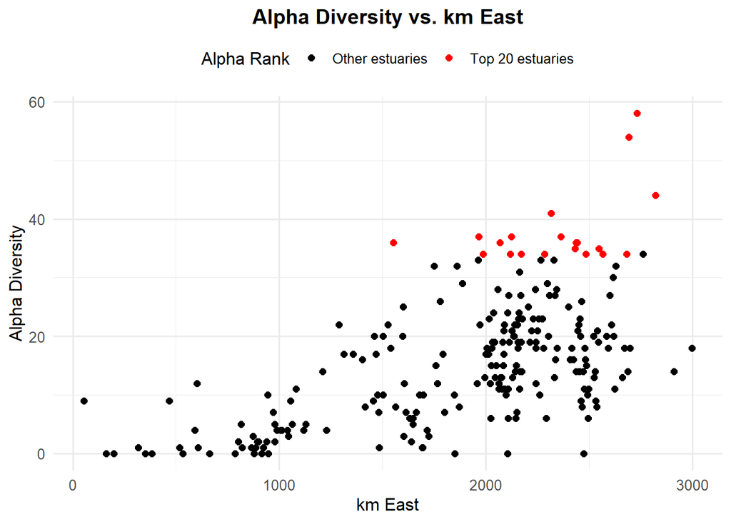

```r
g4 <- ggplot(EF, aes(x = kmEast, y = alpha)) +
  geom_point(aes(color = factor(AlphaList)), size = 2) +
    scale_color_manual(
    values = c("0" = "black", "1" = "red"),
    labels = c("Other estuaries", "Top 20 estuaries"),
    name = "Alpha Rank"
  ) +
  theme_minimal(base_size = 12) +
  labs(
    title = "Alpha Diversity vs. km East",
    x = "km East",
    y = "Alpha Diversity"
  ) +
  theme(
    plot.title = element_text(face = "bold", hjust = 0.5),
    axis.title = element_text(size = 12),
    axis.text = element_text(size = 10),
    legend.position = "top"
  )

g4
```

## Alpha Method

Now we need to list the top 20 esturaries and save it into a variable

```r
AlphaList <- EF[1:20, 1]
AlphaList
```

```
##  [1] Mlalazi        Matigulu/Nyoni St Lucia       Mngazana       Kariega
##  [6] Kwelera        Mntafufu       Knysna         Tyolomnqa      Mzamba
## [11] Mtamvuna       Mtentu         Mkomazi        Kowie          Gqunube
## [16] Ngqusi/Inxaxo  Mtata          Mzimkulu       Lovu           Zinkwasi
## 231 Levels: Orange Buffels Swartlintjies Spoeg Groen Sout (North) ... Kosi
```

We want the list and the number of species. 0 represents the species not in the list; 1 represents the species that is in the list.

```r
AlphaSpp <- specnumber(EF[,4:148] , EF$AlphaList)
AlphaSpp
```

```
##   0   1
## 121 116
```

There are 116 species in the list and 145 species in total. So, we calculate the percentage of species within the list.

```r
AlphaPerc <- (116/145) *100
AlphaPerc
```

```
## [1] 80
```

## Change the metric

Now do the same for the SW index. Start by reordering the dataframe

```r
EF <- EF[order(-EF$SW), ]
```

Creating new variable

```r
EF$SW_list <- 0
EF$SW_list[1:20] <- 1
```

[figure not shown]

```r
g5 <- ggplot(EF, aes(x = kmEast, y = alpha)) +
  geom_point(aes(color = factor(SW_list)), size = 2) +
    scale_color_manual(
    values = c("0" = "black", "1" = "red"),
    labels = c("Other estuaries", "Top 20 estuaries"),
    name = "SW Rank"
  ) +
  theme_minimal(base_size = 12) +
  labs(
    title = "SW index vs. km East",
    x = "km East",
    y = "SW"
  ) +
  theme(
    plot.title = element_text(face = "bold", hjust = 0.5),
    axis.title = element_text(size = 12),
    axis.text = element_text(size = 10),
    legend.position = "top"
  )

g5
```

## SW Method Now we need to list the top 20 esturaries and save it into a variable

```r
SW_list <- EF[1:20, 1]
SW_list
```

```
##  [1] Mkomazi          Mlalazi          Mtentu           Mzamba
##  [5] Mhlali           Matigulu/Nyoni   Mtamvuna         Mzimkulu
##  [9] Mfolozi/Msunduzi Sinangwana       Great Kei        Mahlongwa
## [13] Bushmans         Mgeni            Mntafufu         St Lucia
## [17] Umhlangankulu    Knysna           Mngazi           Mapuzi
## 231 Levels: Orange Buffels Swartlintjies Spoeg Groen Sout (North) ... Kosi
```

We want the list and the number of species. 0 represents the species not in the list; 1 represents the species that is in the list.

```r
SW_spp <- specnumber(EF[,4:148] , EF$SW_list)
SW_spp
```

```
##   0   1
## 125 110
```

There are 110 species in the list and 145 species in total. So, we calculate the percentage of species within the list.

```r
SW_perc <- (110/145) *100
SW_perc
```

```
## [1] 75.86207
```

## Biogeographic Zonation

Use specnumber to calculate the species number per biogeographic zone (BZ)

```r
specnumber(EF[,4:148], EF$BZ)
```

```
##   E   S   W
## 111  79  21
```

In each of the 3 zones, choose the most diverse estuary in each zone. Choose 6 estuaries from each zone (2 spare). 6 from W; 7 from S; 7 from E. Start ordering the data frame by BZ then by alpha.

```r
EF <- EF[order(EF$BZ, -EF$alpha), ]
head(EF)
```

[output not shown]

[output cut: 209 more lines]

Creating a list

```r
EF$BZ_list <- 0

top_n <- c(W = 6, S = 7, E = 7)

for (z in names(top_n)) {
  zone_rows <- which(EF$BZ == z)
  EF$BZ_list[head(zone_rows, top_n[z])] <- 1
}
```

Creating the plot

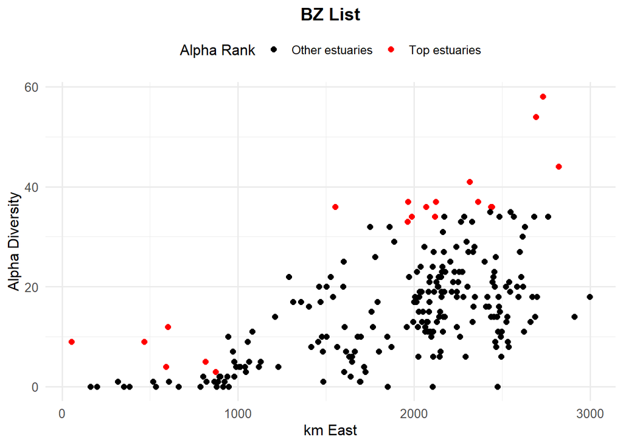

```r
g6 <- ggplot(EF, aes(x = kmEast, y = alpha)) +
  geom_point(aes(color = factor(BZ_list)), size = 2) +
    scale_color_manual(
    values = c("0" = "black", "1" = "red"),
    labels = c("Other estuaries", "Top estuaries"),
    name = "Alpha Rank"
  ) +
  theme_minimal(base_size = 12) +
  labs(
    title = "BZ List",
    x = "km East",
    y = "Alpha Diversity"
  ) +
  theme(
    plot.title = element_text(face = "bold", hjust = 0.5),
    axis.title = element_text(size = 12),
    axis.text = element_text(size = 10),
    legend.position = "top"
  )

g6
```

We want the list and the number of species. 0 represents the species not in the list; 1 represents the species that is in the list.

```r
BZ_spp <- specnumber(EF[, 4:148], EF$BZ_list)
BZ_spp
```

```
##   0   1
## 120 122
```

There are 122 species in the list and 145 species in total. So, we calculate the percentage of species within the list.

```r
BZ_perc <- (122/145) *100
BZ_perc
```

```
## [1] 84.13793
```

## Dendrogam

We have things called biogeographical zones, each with their own sets of species. When 2 zones come together (overlap), that is where you get the most species. But that is not good to protect. The edges have more diversity but we need to protect the centre. The edges have high diversity and are not good for protection because they are a mix and not atrue measure of diversity. We do multivariate. We find if the ecosystem falls into groups and then we identify the estuaries that fall into these ecossytem groups. To do this, we make use of a dendrogram.

Create a dendrogram based on species composition. ‘vegan’ plays a key role in this process. Pairwise comparisons between each estuary to develop an index of similarity in species composition.

```r
EF <- subset(EF, alpha > 0)  #subset the data due to the 0s

EF_deco <- decostand(EF[,4:148], method = 'total')
```

## Bray-Curtis

Bray-Curtis most commonly used index for similarity. Especially when there are many 0s, Bray-CUrtis is a good fit.

```r
EF_dist <- vegdist(EF_deco, method =  'bray')
```

## H-clust and V-clust

H-clust is horizontal and v-clust is vertical.

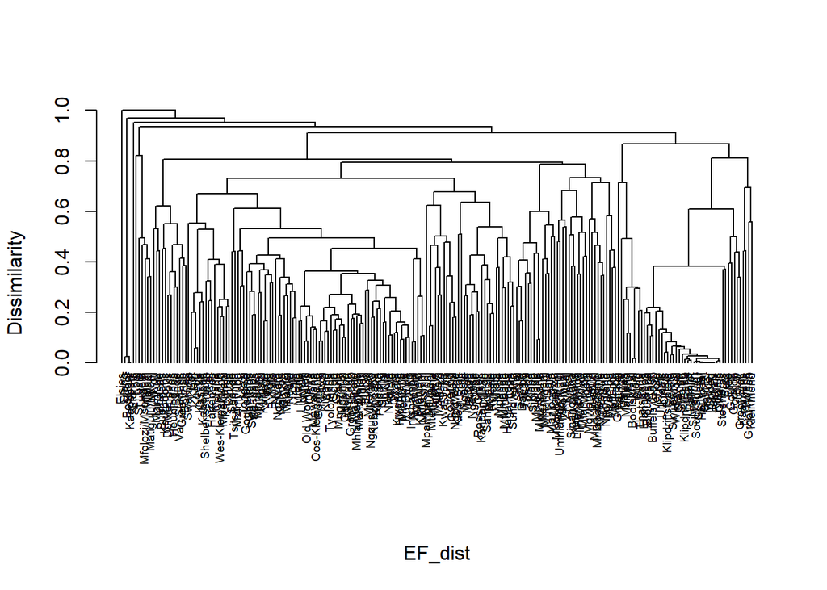

```r
EF_clust <- hclust(EF_dist, method = "average") # run clustering

plot(
  EF_clust,
  labels = EF$Estuary,
  hang = -1,
  cex = 0.6,
  main = NULL,
  ylab = "Dissimilarity",
  sub = "",
  col = "black"
)
```

Reduce the tree

```r
slice <- cutree(EF_clust,
                h= 0.8)
slice
```

[output not shown]

```r
EF$Slice80 <- slice #adding into data frame
```

Ordering data by slice then alpha

```r
EF <- EF[order(EF$Slice80, -EF$alpha), ]
```

```r
# Initialize the Slice80_list column to 0
EF$Slice80_list <- 0

# Loop through each unique Slice80 group
for (g in unique(EF$Slice80)) {

  # Find all rows in the group
  group <- which(EF$Slice80 == g)

  # Determine how many rows to score
  top_n <- if (g == "2") {
    4
  } else if (g == "3") {
    3
  } else {
    2
  }

  # Always score at least 1 row (if only 1 available)
  EF$Slice80_list[group[1:min(top_n, length(group))]] <- 1
}
```

## Plots

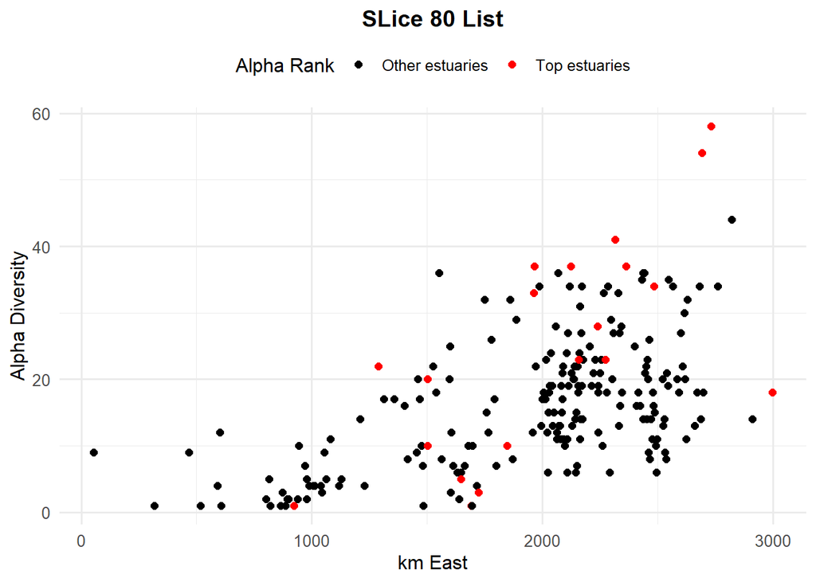

```r
g7 <- ggplot(EF, aes(x = kmEast, y = alpha)) +
  geom_point(aes(color = factor(Slice80_list)), size = 2) +
    scale_color_manual(
    values = c("0" = "black", "1" = "red"),
    labels = c("Other estuaries", "Top estuaries"),
    name = "Alpha Rank"
  ) +
  theme_minimal(base_size = 12) +
  labs(
    title = "SLice 80 List",
    x = "km East",
    y = "Alpha Diversity"
  ) +
  theme(
    plot.title = element_text(face = "bold", hjust = 0.5),
    axis.title = element_text(size = 12),
    axis.text = element_text(size = 10),
    legend.position = "top"
  )

g7
```

List the species in the groups

```r
Slice80_spp <- specnumber(EF[,4:148], EF$Slice80_list)
Slice80_spp
```

```
##   0   1
## 129 100
```

There are 100 species in the list and 145 species in total. So, we calculate the percentage of species within the list.

```r
Slice80_perc <- (100/145) *100
Slice80_perc
```

```
## [1] 68.96552
```

## The Range Centre Method

Calculate the range

```r
# species abundance data
spp <- EF[, 4:148]

# distance from eastern boundary
coords <- EF$kmEast
```

Now we need to calculate the range for each species. We can create a function to do this.

```r
range_stats <- function(abundance, coords) {
  present_coords <- coords[abundance > 0]  # get kmEast values where species is present

  if (length(present_coords) == 0) {
    # species not present anywhere
    return(c(west_limit = NA, east_limit = NA, center = NA))
  } else {
    east <- min(present_coords)                    # furthest west point
    west <- max(present_coords)                    # furthest east point
    centre <- mean(c(east, west))                  # center of range

    return(c(east_limit = east, west_limit = west, centre = centre))
  }
}

# Apply the function across all species (columns)
spp_range <- t(apply(spp, 2, range_stats, coords = coords))
```

Now we just need to plop our results into a dataframe which contains the species names as well as their west_limit, east_limit and centre values.

```r
# convert result to a clean data frame
spp_range_list <- data.frame(
  Species = colnames(spp),  # species names from column headers
  spp_range                 # range stats: west, east, center
)

# preview first few rows of the result
head(spp_range_list)
```

```
##                           Species east_limit west_limit centre
## Spot.damsel           Spot.damsel       2997       2997 2997.0
## Estuarine.bream   Estuarine.bream       1966       2821 2393.5
## Bald.glassy           Bald.glassy       1861       2821 2341.0
## Slender.glassy     Slender.glassy       2255       2997 2626.0
## Longspine.glassy Longspine.glassy       2119       2997 2558.0
## Evileye.blaasop   Evileye.blaasop        969       2733 1851.0
```

Now we can plot a histogram with the frequency of range centres per 100 km.

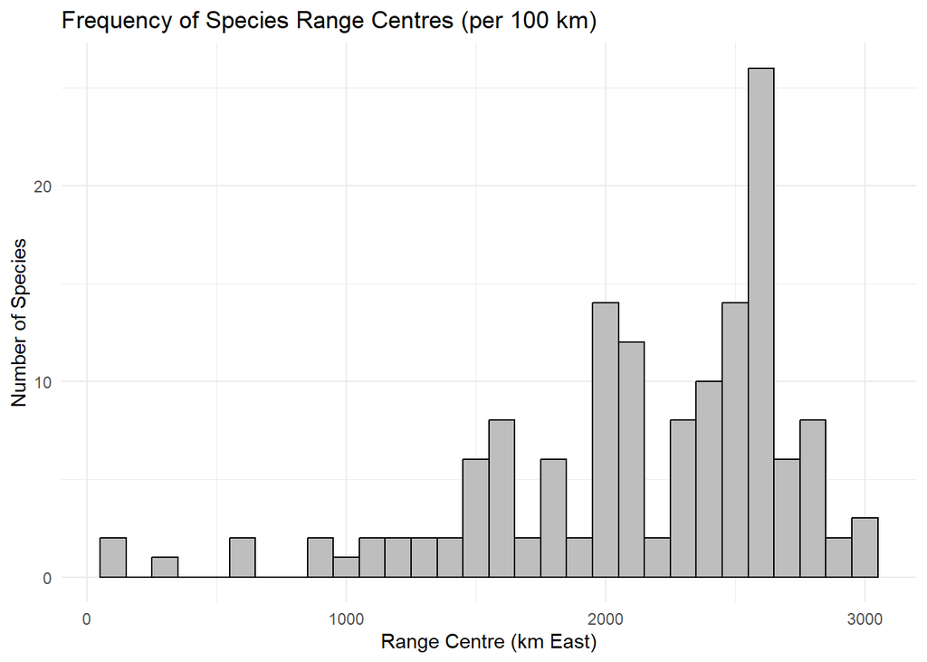

```r
g8<- ggplot(spp_range_list, aes(x = centre)) +
  geom_histogram(binwidth = 100, fill = "grey", color = "black") +
  xlab("Range Centre (km East)") +
  ylab("Number of Species") +
  ggtitle("Frequency of Species Range Centres (per 100 km)") +
  theme_minimal()

g8
```

Extract frequencies from histogram and add that to the original data frame

```r
EF$block <- ceiling(EF$kmEast/100)

EF$RC_list <- 1

EF <- EF[order(EF$kmEast),]

interval_table <- table(cut(spp_range_list$centre,seq(0,3000,100)))
print(order(interval_table, decreasing = TRUE))
```

```
##  [1] 26 25 27 20 21 16 24 22 29 18 15 17 19 23 28 30  1  7 10 12 13 14  3  9 11
## [26]  2  4  5  6  8
```

```r
# Define blocks to score as 0
zero_blocks <- c(13, 14, 3, 9, 11, 2, 4, 5, 6, 8)

# Loop through each row
for (i in 1:nrow(EF)) {
  if (EF$block[i] %in% zero_blocks) {
    EF$RC_list[i] <- 0
  }
}
```

Subset data and remove the zeros

```r
EF <- subset(EF, RC_list > 0)
```

Order data by block and alpha

```r
EF <- EF[order(EF$block, -EF$alpha), ]
```

Assigning max

```r
max <- EF$alpha[1]  # Initialize max with the first alpha value
EF$RC_list <- 0
EF$RC_list[1] <- 1

for (j in 2:nrow(EF)) {
  if (EF$block[j] > EF$block[j-1]) {
    max <- 0
    if (EF$alpha[j] > max) {
     EF$RC_list[j] <- 1
    max <- EF$alpha[j]
    }
  } else if (EF$block[j] == EF$block[j-1]) {
    if (EF$alpha[j] > max) {
      EF$RC_list[j] <- 1
      EF$RC_list[j-1] <- 0
      max <- EF$alpha[j]
    }
  }
}

sum(EF$RC_list)
```

```
## [1] 20
```

List the species in the groups

```r
RC_spp <- specnumber(EF[,4:148], EF$RC_list)
RC_spp
```

```
##   0   1
## 117 121
```

There are 121 species in the list and 145 species in total. So, we calculate the percentage of species within the list.

```r
RC_perc <- (121/145) *100
RC_perc
```

```
## [1] 83.44828
```